# Practical 6: Mixed effects models

Author

Benjamin Rosenbaum

We perform some classical linear modeling with a random grouping factor. Predictions etc can be computed with random effects, or fixed effects only. Model checks, model comparisons, hypotheses, etc are the same as with linear models.

```r
rm(list=ls())
library("brms")
library("ggplot2")
library("performance")
library("ecostats")
library("cowplot")
try(dev.off())
```

# Random interceps ANOVA

From Warton, D. (2022) Eco-Stats: Data Analysis in Ecology

Counted number of invertebrate species in samples from different estuaries. Estuaries are either pristine or modified. Data are grouped, originate from 7 estuaries with multiple samples per estuary.

**Question:** Is there a difference in species richness between modified and pristine estuaries?

The random grouping factor `Estuary` is nested in `Mod`, because each Estuary is either modified or pristine. We could model this as `(1|Mod/Estuary)`, but since `Mod` only has two levels, of which we are interested in species difference, we model `Mod` as fixed effect with random effects for `Estuary`.

```r
data("estuaries")
table(estuaries$Mod, estuaries$Estuary)
```

```
           BOT CLY HAK JAK JER KEM WAG
  Modified   6   0   0   7   0   5   0
  Pristine   0   4   7   0   7   0   6
```

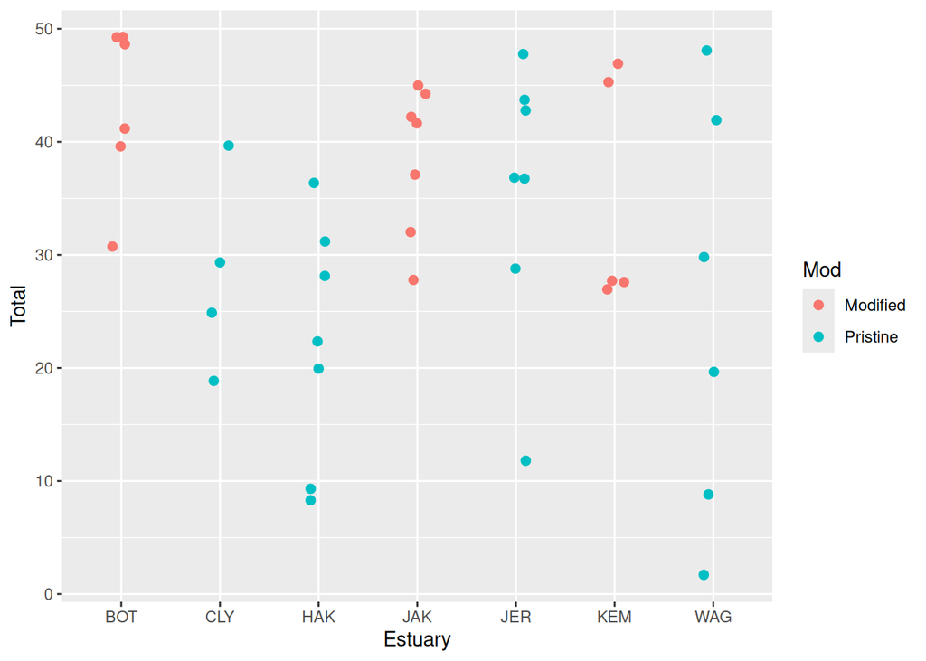

```r
ggplot(estuaries, aes(Estuary, Total, col=Mod)) + geom_jitter(width=0.1, size=2)
```

Remove NAs. brms automatically removes them in model fitting. But when different predictors have NAs for different observations, models that do not have the same predictors might end up with different datasets. In this case, model comparison would not be possible (requires identical datasets).

```r
ID.complete = complete.cases(estuaries[, c("Total","Mod","Estuary","Temperature")])
estuaries = estuaries[ID.complete, ]
```

Deterministic part: $\mu_i=b(Mod_i)+\delta(Estuary_i)$  
Stochastic part: $Total_i \sim \text{Normal}(\mu_i, \sigma)$  
Hierarchical part: $\delta_j \sim \text{Normal}(0, \sigma_{Est})$

$i=1\dots N$, $Mod=1,2$, $Estuary=1\dots7$

```r
default_prior(Total ~ Mod+(1|Estuary), data=estuaries)
```

```
                  prior     class        coef   group resp dpar nlpar lb ub       source
                 (flat)         b                                                default
                 (flat)         b ModPristine                               (vectorized)
 student_t(3, 32, 14.8) Intercept                                                default
  student_t(3, 0, 14.8)        sd                                      0         default
  student_t(3, 0, 14.8)        sd             Estuary                  0    (vectorized)
  student_t(3, 0, 14.8)        sd   Intercept Estuary                  0    (vectorized)
  student_t(3, 0, 14.8)     sigma                                      0         default
```

We only need to specify a prior for the fixed effect (which is dummy-coded), the random effects part is already taken care of by default.

```r
fit.est.1 = brm(Total ~ Mod+(1|Estuary),
                prior = prior(normal(0,10), class=b),
                data = estuaries)
```

Note that `summary()` and `plot()` do not display the actual random effects $\delta_j$, only their sdev $\sigma_{Estuary}=$`sd(Intercept)`

```r
summary(fit.est.1, prior=TRUE)
```

```
 Family: gaussian
  Links: mu = identity; sigma = identity
Formula: Total ~ Mod + (1 | Estuary)
   Data: estuaries (Number of observations: 41)
  Draws: 4 chains, each with iter = 2000; warmup = 1000; thin = 1;
         total post-warmup draws = 4000

Priors:
b ~ normal(0, 10)
Intercept ~ student_t(3, 32, 14.8)
<lower=0> sd ~ student_t(3, 0, 14.8)
<lower=0> sigma ~ student_t(3, 0, 14.8)

Multilevel Hyperparameters:
~Estuary (Number of levels: 7)
              Estimate Est.Error l-95% CI u-95% CI Rhat Bulk_ESS Tail_ESS
sd(Intercept)     5.11      3.35     0.35    13.39 1.00      928     1367

Regression Coefficients:
            Estimate Est.Error l-95% CI u-95% CI Rhat Bulk_ESS Tail_ESS
Intercept      37.45      4.00    28.90    45.02 1.00     1485     1511
ModPristine    -8.96      5.11   -18.45     1.91 1.00     1475     1761

Further Distributional Parameters:
      Estimate Est.Error l-95% CI u-95% CI Rhat Bulk_ESS Tail_ESS
sigma    11.24      1.39     8.90    14.29 1.00     2437     2535

Draws were sampled using sampling(NUTS). For each parameter, Bulk_ESS
and Tail_ESS are effective sample size measures, and Rhat is the potential
scale reduction factor on split chains (at convergence, Rhat = 1).
```

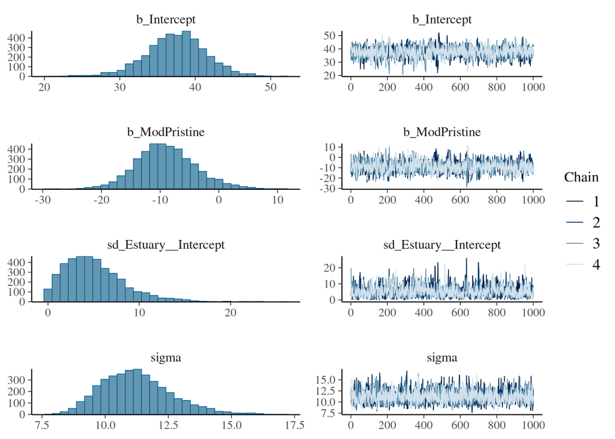

```r
plot(fit.est.1)
```

If needed, fixed and random effects can be extracted with these functions:

```r
fixef(fit.est.1)
```

```
            Estimate Est.Error      Q2.5     Q97.5
Intercept   37.44954  4.003155  28.89980 45.022357
ModPristine -8.96339  5.108531 -18.45213  1.912913
```

```r
ranef(fit.est.1)
```

```
$Estuary
, , Intercept

      Estimate Est.Error       Q2.5     Q97.5
BOT  2.9199439  4.401671  -4.001824 13.455701
CLY -0.1883263  4.088938  -8.995330  7.894171
HAK -3.4409207  4.343956 -13.633125  3.606532
JAK  0.7751533  4.044399  -7.270259  9.503657
JER  3.4372259  4.163375  -3.426794 13.033421
KEM -0.9766246  4.088095  -9.849672  7.344053
WAG -3.1842804  4.438557 -13.908306  3.926569
```

Conditional effects plots of fixed effects only (default, “population-level”), but by specifying `re_formula=NULL` and `conditions`, we can plot on group-level, too. We even get predictions (on group-level) of what would happen if we applied the modification to the estuary instead of keeping it pristine.

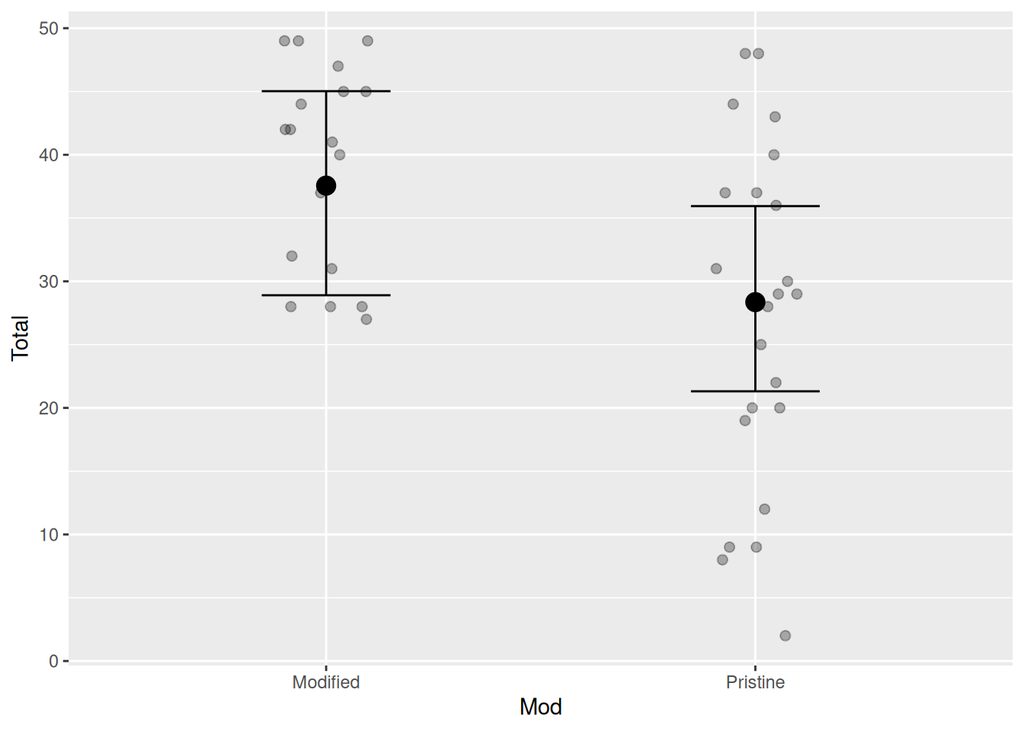

```r
plot(conditional_effects(fit.est.1),
     points=T,
     point_args=c(alpha=0.3, width=0.1))
```

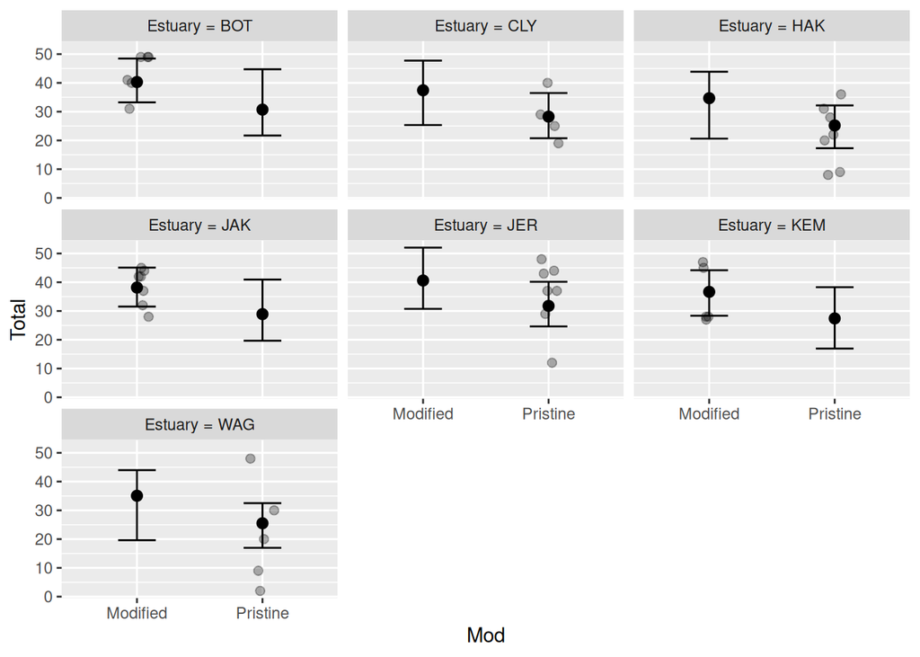

```r
plot(conditional_effects(fit.est.1,
                         re_formula = NULL,
                         conditions = make_conditions(fit.est.1, var=c("Estuary"))),
     points=T,
     point_args=c(alpha=0.3, width=0.1, size=2))
```

When computing predictions with `fitted` (deterministic part) or `predict` (deterministic & stochastic part), we can choose to include random effects (default), or fixed effects only with `re_formula=NA`.

In general, `re_formula=NULL` **enforces** random effects, `re_formula=NA` **omits** random effects.

```r
fitted(fit.est.1) |> head()
```

```
     Estimate Est.Error    Q2.5    Q97.5
[1,] 38.22469  3.459319 31.5402 45.08605
[2,] 38.22469  3.459319 31.5402 45.08605
[3,] 38.22469  3.459319 31.5402 45.08605
[4,] 38.22469  3.459319 31.5402 45.08605
[5,] 38.22469  3.459319 31.5402 45.08605
[6,] 38.22469  3.459319 31.5402 45.08605
```

```r
fitted(fit.est.1, re_formula=NA) |> head()
```

```
     Estimate Est.Error    Q2.5    Q97.5
[1,] 37.44954  4.003155 28.8998 45.02236
[2,] 37.44954  4.003155 28.8998 45.02236
[3,] 37.44954  4.003155 28.8998 45.02236
[4,] 37.44954  4.003155 28.8998 45.02236
[5,] 37.44954  4.003155 28.8998 45.02236
[6,] 37.44954  4.003155 28.8998 45.02236
```

Finally, we check the model fit. Again, we can choose to use predictions with random effects (default) and compute the **conditional R2**, while without random effects (`re_formula=NA`) we compute the **marginal R2.**

```r
bayes_R2(fit.est.1) # conditional (default)
```

```
    Estimate Est.Error       Q2.5     Q97.5
R2 0.2695999  0.104506 0.06138227 0.4586746
```

```r
bayes_R2(fit.est.1, re_formula=NULL) # conditional (the same)
```

```
    Estimate Est.Error       Q2.5     Q97.5
R2 0.2695999  0.104506 0.06138227 0.4586746
```

```r
bayes_R2(fit.est.1, re_formula=NA) # marginal
```

```
    Estimate Est.Error         Q2.5     Q97.5
R2 0.1543518 0.1097426 0.0007859223 0.3845651
```

Model checks use random effects per default, but can also be done with fixed effects only if required.

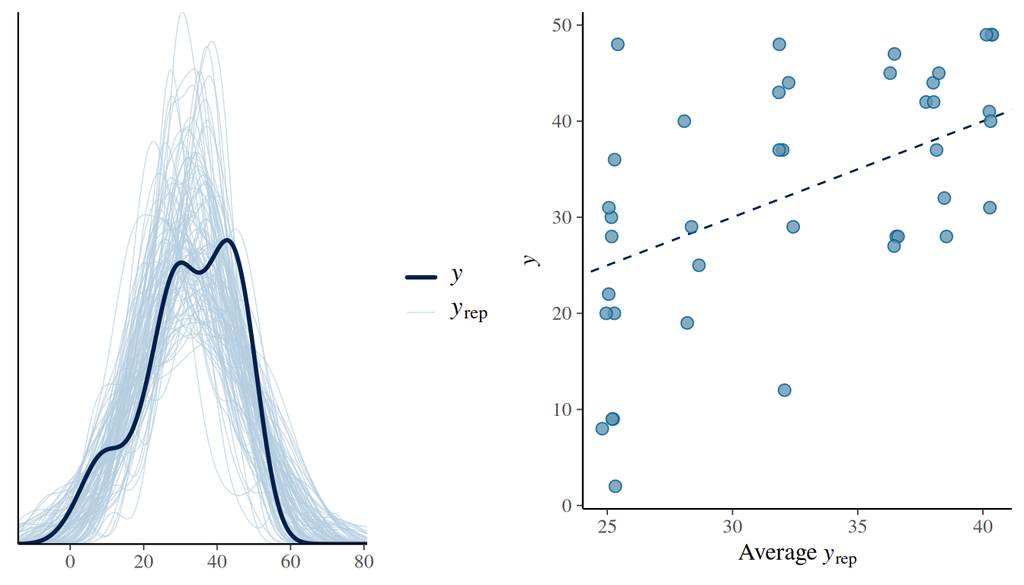

```r
p1 = pp_check(fit.est.1, ndraws=100)
p2 = pp_check(fit.est.1, type="scatter_avg")
plot_grid(p1,p2)
```

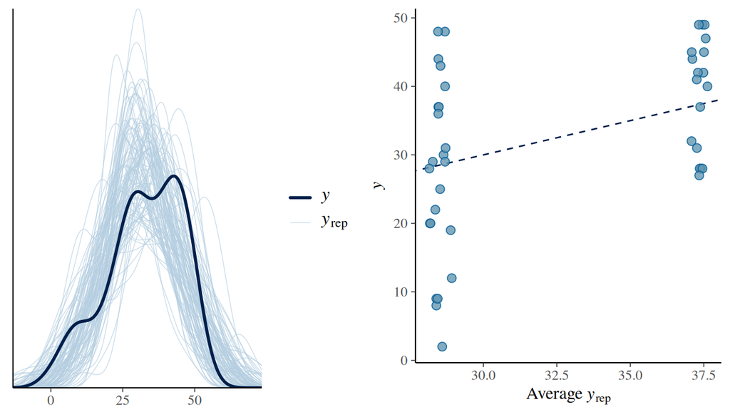

```r
p1 = pp_check(fit.est.1, ndraws=100, re_formula=NA)
p2 = pp_check(fit.est.1, type="scatter_avg", re_formula=NA)
plot_grid(p1,p2)
```

Since this is a linear model, we can assess model assumptions with `check_model()`

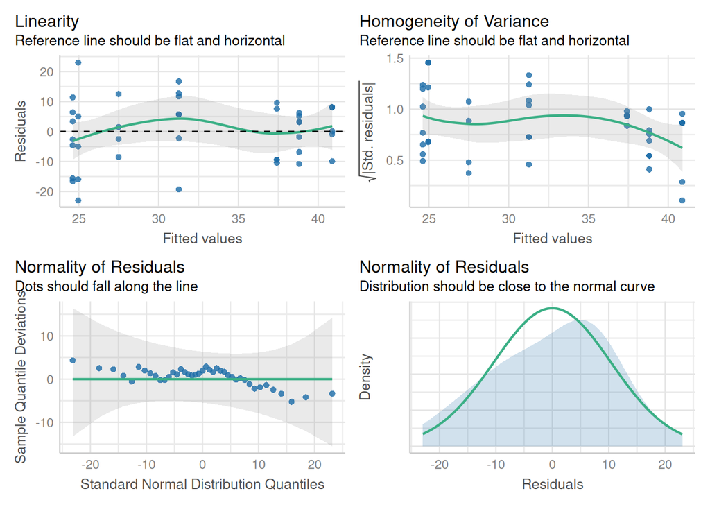

```r
check_model(fit.est.1, check=c("linearity","homogeneity","qq","normality"))
```

It also provides an additional check for normality of random effects

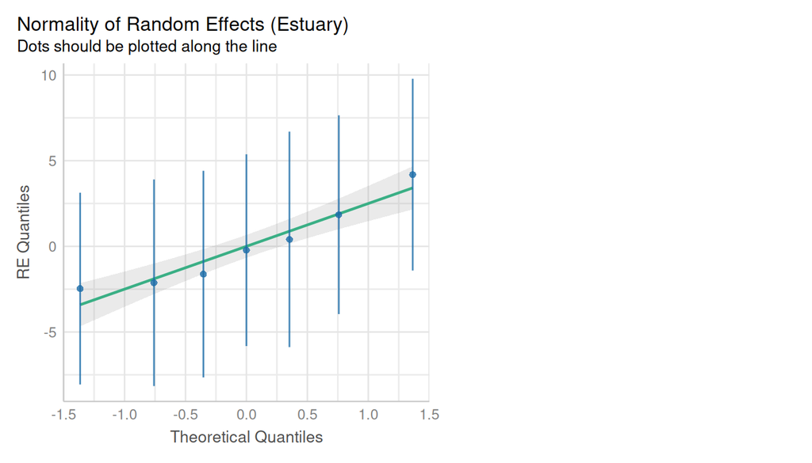

```r
check_model(fit.est.1, check=c("reqq"))
```

The summary table already tells us that the difference between pristine and modified estuaries `ModPristine` is -8.96, 95% CI [-18.45,1.91]. Or we use the `hypothesis` function. Note that here we get 90% CIs. But `Post.Prob` is the quantity of interest here

```r
hypothesis(fit.est.1, "ModPristine<0")
```

```
Hypothesis Tests for class b:
         Hypothesis Estimate Est.Error CI.Lower CI.Upper Evid.Ratio Post.Prob Star
1 (ModPristine) < 0    -8.96      5.11   -16.83    -0.15      20.28      0.95    *
---
'CI': 90%-CI for one-sided and 95%-CI for two-sided hypotheses.
'*': For one-sided hypotheses, the posterior probability exceeds 95%;
for two-sided hypotheses, the value tested against lies outside the 95%-CI.
Posterior probabilities of point hypotheses assume equal prior probabilities.
```

If we had fitted the model **without random intercepts** (complete pooling), the model would be overly confident in the Modified-Pristine difference (uncertainty is smaller here):

```r
fit.est.compl = brm(Total ~ Mod,
                    prior = prior(normal(0,10), class=b),
                    data = estuaries)
```

```r
fixef(fit.est.compl)
```

```
             Estimate Est.Error      Q2.5     Q97.5
Intercept    38.27533  2.653983  33.15225 43.339139
ModPristine -10.46960  3.453143 -17.11447 -3.830119
```

```r
fixef(fit.est.1)
```

```
            Estimate Est.Error      Q2.5     Q97.5
Intercept   37.44954  4.003155  28.89980 45.022357
ModPristine -8.96339  5.108531 -18.45213  1.912913
```